# A Statistical Analysis of Sleep - Quality and Duration

Paolo Ciracì, Niccolò Disassonia

2025-05-30

## Chapter 1 - Introduction

### Dataset cleaning and preprocessing

In this presentation, we take into analysis a data set (Cutting 2025) in which data about sleep is collected among with other body parameters, in order to study how different variables affect its quality. First of all, we present the data set and briefly explain each one of its variable.

```r
sleep <- read.csv('Sleep_health_and_lifestyle_dataset.csv', header = T)
head(sleep)
```

```
##   Person.ID Gender Age           Occupation Sleep.Duration Quality.of.Sleep
## 1         1   Male  27    Software Engineer            6.1                6
## 2         2   Male  28               Doctor            6.2                6
## 3         3   Male  28               Doctor            6.2                6
## 4         4   Male  28 Sales Representative            5.9                4
## 5         5   Male  28 Sales Representative            5.9                4
## 6         6   Male  28    Software Engineer            5.9                4
##   Physical.Activity.Level Stress.Level BMI.Category Blood.Pressure Heart.Rate
## 1                      42            6   Overweight         126/83         77
## 2                      60            8       Normal         125/80         75
## 3                      60            8       Normal         125/80         75
## 4                      30            8        Obese         140/90         85
## 5                      30            8        Obese         140/90         85
## 6                      30            8        Obese         140/90         85
##   Daily.Steps Sleep.Disorder
## 1        4200           None
## 2       10000           None
## 3       10000           None
## 4        3000    Sleep Apnea
## 5        3000    Sleep Apnea
## 6        3000       Insomnia
```

```r
dim(sleep)
```

```
## [1] 374  13
```

Before proceeding with the analysis, we must do some adjustments to the data set: first of all, we remove the first column, that is **Person.ID** since we don’t need it. Secondly, we check for missing data and if we found some, we delete the whole row involved. Finally we transform all the quantitative variables into factor variables: this is done in order to be able to apply correctly all the different functions for estimating the models later on.

```r
#Delete first column
sleep <- sleep[, -1]

#Check for NAs
sum(is.na(sleep)) #0, so the data set is ok
```

```
## [1] 0
```

```r
#From chr to factor variables
sleep$Gender <- factor(sleep$Gender)
sleep$Occupation <- factor(sleep$Occupation)
sleep$Quality.of.Sleep <- factor(sleep$Quality.of.Sleep)
sleep$Blood.Pressure <- factor(sleep$Blood.Pressure)
sleep$Stress.Level <- factor(sleep$Stress.Level)
sleep$Sleep.Disorder <- factor(sleep$Sleep.Disorder)
```

We focus one moment on the **BMI.Category** variable separately:

```r
factor(sleep$BMI.Category)[1:20]
```

```
##  [1] Overweight    Normal        Normal        Obese         Obese
##  [6] Obese         Obese         Normal        Normal        Normal
## [11] Normal        Normal        Normal        Normal        Normal
## [16] Normal        Normal Weight Normal        Normal Weight Normal
## Levels: Normal Normal Weight Obese Overweight
```

We see that we have two classes which are *Normal Weight* and *Normal*: we can assume that both these tags signify the same BMI category for an individual, and that it was just an error in recording data. Hence, what we do is to replace them, reducing the variable in having three categories and then we convert it into a factor variable:

```r
sleep$BMI.Category[sleep$BMI.Category == 'Normal Weight'] <- 'Normal'
sleep$BMI.Category <- factor(sleep$BMI.Category)
```

The last adjustment we do is to the **Quality.of.Sleep** and **Stress.Level** variables: as we said above, these have $6$ classes, which however don’t begin from $1$ to $6$, so we adjust this for making some things more simple later and because they then make more sense.

```r
levels(sleep$Quality.of.Sleep) <- 1:6
levels(sleep$Stress.Level) <- 1:6
```

We are finally ready to analyze this data set.

### Descriptive Analysis of the variables

Before beginning, we briefly analyze some variables in a descriptive manner:

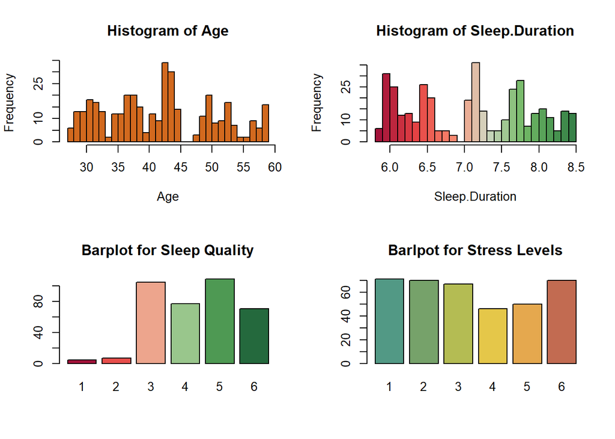

```r
attach(sleep)
par(mfrow = c(2, 2))
hist(Age, 25, col = 'chocolate')
hist(Sleep.Duration, 20, col = paletteer_c("ggthemes::Red-Green Diverging", 30))
barplot(table(Quality.of.Sleep), col = paletteer_c("ggthemes::Red-Green Diverging", 6), main = 'Barplot for Sleep Quality')
barplot(table(Stress.Level), col = paletteer_c("ggthemes::Temperature Diverging", 6),
        main = 'Barlpot for Stress Levels')
```

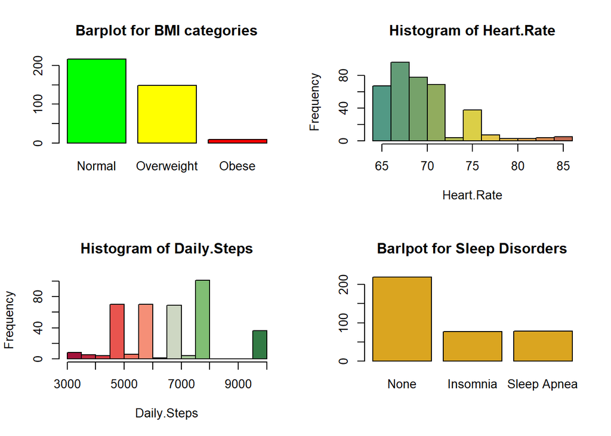

```r
#par(mfrow = c(2, 2))
barplot(table(BMI.Category)[c(1, 3, 2)], col = c('green', 'yellow', 'red'), main = 'Barplot for BMI categories')
hist(Heart.Rate, col = paletteer_c("ggthemes::Temperature Diverging", 11))
hist(Daily.Steps, col = paletteer_c("ggthemes::Red-Green Diverging", 15))
barplot(table(Sleep.Disorder)[c(2, 1, 3)], col = 'goldenrod', main = 'Barlpot for Sleep Disorders')
```

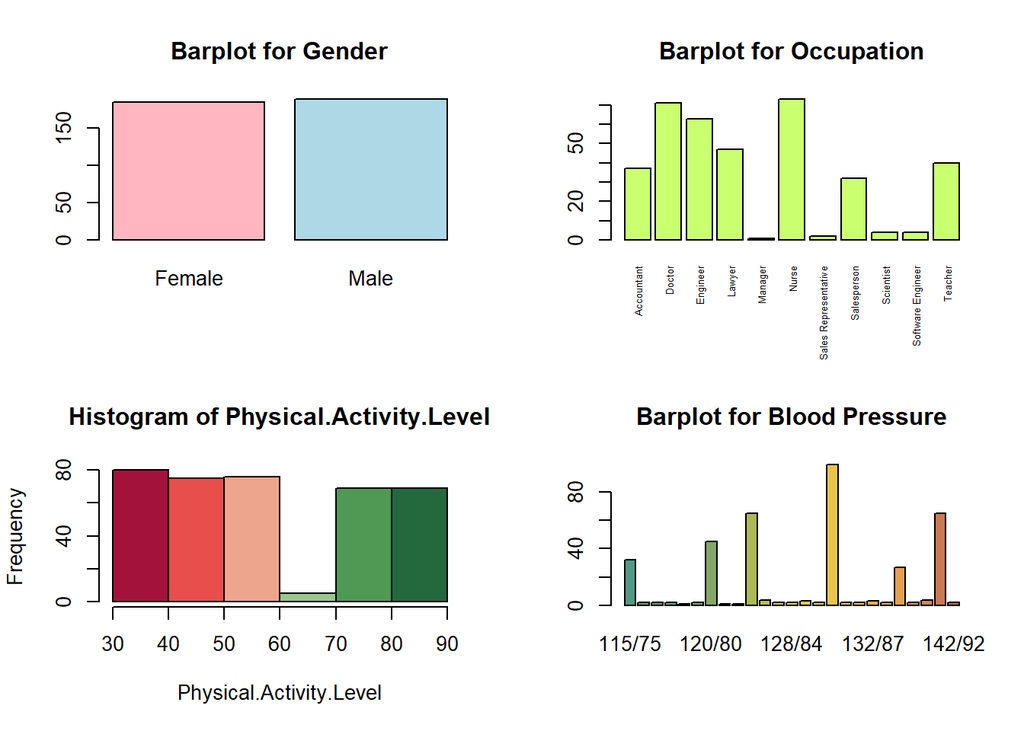

```r
#par(mfrow = c(2, 2))
barplot(table(Gender), col = c('lightpink', 'lightblue'), main = 'Barplot for Gender')
barplot(table(Occupation), col = 'darkolivegreen1', main = 'Barplot for Occupation', cex.names = .5, las = 3)
hist(Physical.Activity.Level, 6, col = paletteer_c("ggthemes::Red-Green Diverging", 6))
barplot(table(Blood.Pressure), col = paletteer_c("ggthemes::Temperature Diverging", 25), main = 'Barplot for Blood Pressure')
```

```r
detach(sleep)
```

We can notice how in some categorical variables there are classes with very few observations, compared to other classes of the same predictor (e.g., **Quality.of.Sleep**, **BMI.Category**, …): this could be a problem later when we have to fit some models. If we have to, we will partially fix this issue when needed.

Now we briefly look if there is any strong relation between some variables by computing a Pearson correlation matrix. Before doing so, since different variables in the data set are categorical (not continuous) we feel the need to explain why it makes sense to compute the Pearson correlation anyway: the important thing to look at is whether the categorical variables are of *ordinal* type or not; this means that, for example, the levels in the variable **Stress.Level** are not just numbers to distinguish the different possible levels for that variable, but they express also the intensity of stress that a person feels. The same argument holds for every other categorical variable we have here, except for **Gender**, **Occupation** and **Sleep.Disorder**, which indeed we exclude from the computation. Also, we must be sure to have *enough categories* (at least three) and that these are ‘*evenly spaced*’ (e.g., the categories ‘small’, ‘medium’, ‘large’ are evenly spaced, but ‘very small’, ‘normal’, ‘large’ are not, in terms of ‘distance’). We are aware that it is not the best strategy to use Pearson correlation in this setting, however, since we only need to figure out roughly how variables are related with each other and we won’t use those numbers to draw conclusions, we proceed in this manner anyway.

Practically we need to tell R to treat these variables as if they were numerical, just to compute what we want. We do so with the following:

```r
cor(data.frame(lapply(sleep[, -c(1, 3, 12)], as.numeric)))
```

```
##                                Age Sleep.Duration Quality.of.Sleep
## Age                      1.0000000     0.34470936       0.47373388
## Sleep.Duration           0.3447094     1.00000000       0.88321300
## Quality.of.Sleep         0.4737339     0.88321300       1.00000000
## Physical.Activity.Level  0.1789927     0.21236031       0.19289645
## Stress.Level            -0.4223445    -0.81102303      -0.89875203
## BMI.Category             0.5238809    -0.37763690      -0.30387589
## Blood.Pressure           0.5728129    -0.19170370      -0.14776907
## Heart.Rate              -0.2256062    -0.51645489      -0.65986473
## Daily.Steps              0.0579734    -0.03953254       0.01679141
##                         Physical.Activity.Level Stress.Level BMI.Category
## Age                                  0.17899272  -0.42234448   0.52388088
## Sleep.Duration                       0.21236031  -0.81102303  -0.37763690
## Quality.of.Sleep                     0.19289645  -0.89875203  -0.30387589
## Physical.Activity.Level              1.00000000  -0.03413446   0.07550755
## Stress.Level                        -0.03413446   1.00000000   0.16366541
## BMI.Category                         0.07550755   0.16366541   1.00000000
## Blood.Pressure                       0.27191269   0.11754452   0.73217118
## Heart.Rate                           0.13697098   0.67002646   0.24854982
## Daily.Steps                          0.77272305   0.18682895   0.01594936
##                         Blood.Pressure  Heart.Rate Daily.Steps
## Age                          0.5728129 -0.22560619  0.05797340
## Sleep.Duration              -0.1917037 -0.51645489 -0.03953254
## Quality.of.Sleep            -0.1477691 -0.65986473  0.01679141
## Physical.Activity.Level      0.2719127  0.13697098  0.77272305
## Stress.Level                 0.1175445  0.67002646  0.18682895
## BMI.Category                 0.7321712  0.24854982  0.01594936
## Blood.Pressure               1.0000000  0.28830006  0.11945527
## Heart.Rate                   0.2883001  1.00000000 -0.03030858
## Daily.Steps                  0.1194553 -0.03030858  1.00000000
```

This is a bit ugly, but useful: focusing on the correlation of some possible responses with respect to the other variables we find something interesting: for example, focusing on **Quality.of.Sleep**, we notice that it is highly correlated with: **Age**, **Sleep.Duration**, **Stress.Level**, **Heart.Rate**. While some of them are a bit obvious (e.g. **Quality.of.Sleep** with **Sleep.Duration**), others are not. We can also see these relationships graphically, using scatter plots:

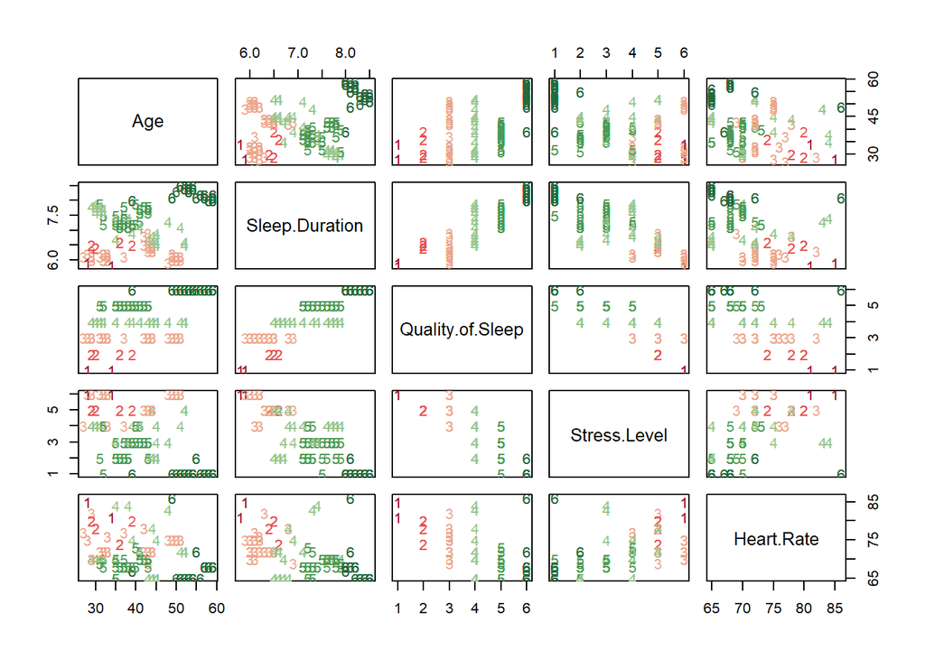

```r
#Colors and symbols used in the plot
lookup<-c('#A3123AFF', '#E84E4BFF', '#EDA58DFF', '#99C68CFF', '#4E9953FF', '#24693DFF')
colors <- rep(0, nrow(sleep))
pchs <- rep(0, nrow(sleep))
for (i in 1:6) {
    colors[sleep$Quality.of.Sleep == i] <- lookup[i]
    pchs[sleep$Quality.of.Sleep == i] <- i + 48
}



pairs(sleep[, c(2, 4, 5, 7, 10)], col = colors, pch = pchs)
```

These are more clear:

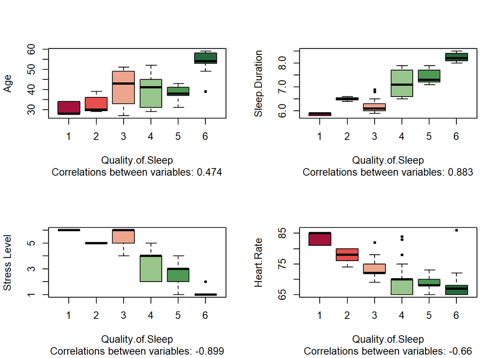

```r
#Extract correlations
correlations <- round(cor(data.frame(lapply(sleep[, c(2, 4, 5, 7, 10)], as.numeric)))[3, c(1, 2, 4, 5)], 3)

#Plots
par(mfrow = c(2, 2))
plot(Age ~ Quality.of.Sleep, sleep, pch = 20,
     col = paletteer_c("ggthemes::Red-Green Diverging", 6),
     sub = paste('Correlations between variables:', correlations[1]))

plot(Sleep.Duration ~ Quality.of.Sleep, sleep, pch = 20,
     col = paletteer_c("ggthemes::Red-Green Diverging", 6),
     sub = paste('Correlations between variables:', correlations[2]))

plot(as.numeric(Stress.Level) ~ Quality.of.Sleep, sleep, pch = 20,
     col = paletteer_c("ggthemes::Red-Green Diverging", 6),
     sub = paste('Correlations between variables:', correlations[3]),
     ylab = 'Stress Level')

plot(Heart.Rate ~ Quality.of.Sleep, sleep, pch = 20,
     col = paletteer_c("ggthemes::Red-Green Diverging", 6),
     sub = paste('Correlations between variables:', correlations[4]))
```

## Chapter 2 - Quality of Sleep Analysis

### Naive Bayes approach

As we saw in the descriptive analysis part, there are a couple interesting variables we could use as our response variable, in particular, two are very tempting: **Quality.of.Sleep** and **Sleep.Duration**; the first is categorical while the latter is quantitative. We will analyze them both since some techniques we would like to apply can’t be used on categorical variables and viceversa.  
For now, we make **Quality.of.Sleep** our response variable, and we set as goal to *build a model which must be able to predict the quality of sleep of an individual, given all the other predictors*and to understand *which variables are the most important for this task*.  
Since we are working with a qualitative response having $L = 6$ classes, our only choice as classification model is some form of Discriminant Analysis. Since different qualitative variables are present as predictors, the best choice is to use Naive Bayes, so that we can estimate discrete distributions for discrete variables using the sample we have available (we cannot assume normal distributions for non-continuous variables!).

The way Naive Bayes works is pretty similar to Linear DA or Quadratic DA: we are always interested in estimating $p_l(\mathbf{x}_i) = \mathbb{P}(y = l | \mathbf{x}_i)$ using Bayes theorem:
$$p_l(\mathbf{x}_i) = \frac{\pi_l f_l(\mathbf{x}_i)}{\sum_{m = 1}^L \pi_m
f_m(\mathbf{x}_i)}$$
for each class $l = 1, ..., L$. We can estimate both $\pi_l$ (prior) and $f_l(\mathbf{x})$ (likelihood) from the sample: the first correspond to the frequency of the $l$-th class in the sample, while the latter is assumed to be a multivariate normal random variable with parameters estimated from the sample; in particular, the vector means is $\mu_l = (\mu_{1l}, ..., \mu_{pl})$ and the variance-covariance matrix is $\Sigma$. Notice that the difference between LDA and QDA is that in the first this matrix is kept constant among all classes $l = 1, ..., L$, while in the latter this changes for each class, so we will have $\Sigma_l$, for $l = 1, ..., L$.

Naive Bayes is pretty similar to the above setup, except that we assume that each predictor has its own distribution and they are all independent. So in symbols we have that $f_l(\mathbf{x}_i) = \prod_{j = 1}^p f_{lj}(x_{ij})$ because of independence and Bayes’ formula becomes:

$$p_l(\mathbf{x}_i) = \frac{\pi_l \prod_{j = 1}^p f_{lj}(x_{ij})}{\sum_{m
= 1}^L \pi_m \prod_{j = 1}^p f_{mj}(x_{ij})}$$

In particular, we assume $f_{lj}$ to be a normal random variable with parameters $(\mu_{lj}, \sigma_{lj}^2)$ if the predictor is continuous, while we assume a discrete random variable if the predictor is categorical, and we estimate its distribution as follows:

$$\mathbb{P}(x = k | y = l) = \frac{1}{n_l} \sum_{i : y_i = l}
\mathbb{1}_{[x_i = k]}, \text{ for } k = 1, ... K$$

where $k$ it the $k$-th class of the categorical variable $\mathbf{x}$, $n_l$ is the total number of observations for class $l$ of the response, and we compute the above for $l = 1, ..., L$. Now we can proceed with the analysis of our data.

First of all, we divide the observations in a training set and a test set to then check predictions accuracy. Then we estimate the model, predict on the test set and look at the results. The procedure we have just described is called the Validation Set approach, and it gives us a *direct* estimate of the test error. In this case, since the response is categorical, we measure the test error using the mis-classification error rate, given by:

$$MSE_{\text{Te}} = \frac{1}{n_{\text{Te}}} \sum_{i : y_i \in \text{Te}}
\mathbb{1}_{\{y_i \neq \hat{y}_i\}}$$
where $\text{Te}$ is the set of test observations, $n_{\text{Te}}$ is the total number of observations in the test set and $\hat{y}_i$ are the predictions for the response made using the model trained on the training set, predicting on test set observations.

```r
set.seed(3)
#Model and predictions
train.index <- sample(1:nrow(sleep), nrow(sleep)/2)
nB <- naiveBayes(Quality.of.Sleep ~ ., data = sleep, subset = train.index)
nB.pred <- predict(nB, sleep[-train.index, ])
nB
```

```
##
## Naive Bayes Classifier for Discrete Predictors
##
## Call:
## naiveBayes.default(x = X, y = Y, laplace = laplace)
##
## A-priori probabilities:
## Y
##          1          2          3          4          5          6
## 0.01604278 0.01604278 0.28342246 0.19251337 0.28877005 0.20320856
##
## Conditional probabilities:
##    Gender
## Y      Female      Male
##   1 0.3333333 0.6666667
##   2 0.3333333 0.6666667
##   3 0.3584906 0.6415094
##   4 0.5000000 0.5000000
##   5 0.3703704 0.6296296
##   6 1.0000000 0.0000000
##
##    Age
## Y       [,1]     [,2]
##   1 30.00000 3.464102
##   2 33.66667 4.041452
##   3 40.67925 7.924581
##   4 39.11111 8.168853
##   5 38.03704 2.834844
##   6 55.15789 3.962843
##
##    Occupation
## Y   Accountant     Doctor   Engineer     Lawyer    Manager      Nurse
##   1 0.00000000 0.00000000 0.00000000 0.00000000 0.00000000 0.00000000
##   2 0.00000000 0.00000000 0.00000000 0.00000000 0.00000000 0.33333333
##   3 0.00000000 0.33962264 0.01886792 0.00000000 0.00000000 0.30188679
##   4 0.08333333 0.44444444 0.00000000 0.02777778 0.00000000 0.02777778
##   5 0.27777778 0.00000000 0.22222222 0.37037037 0.00000000 0.01851852
##   6 0.02631579 0.02631579 0.44736842 0.00000000 0.00000000 0.50000000
##    Occupation
## Y   Sales Representative Salesperson  Scientist Software Engineer    Teacher
```

[output cut: 95 more lines]

```
##   1 3733.333 1270.1706
##   2 4533.333  461.8802
##   3 7109.434 2170.1882
##   4 6752.778 1146.5442
##   5 7337.037  825.6036
##   6 6144.737 1201.9573
##
##    Sleep.Disorder
## Y     Insomnia       None Sleep Apnea
##   1 0.33333333 0.00000000  0.66666667
##   2 0.66666667 0.00000000  0.33333333
##   3 0.30188679 0.35849057  0.33962264
##   4 0.47222222 0.50000000  0.02777778
##   5 0.01851852 0.94444444  0.03703704
##   6 0.00000000 0.52631579  0.47368421
```

```r
#Evaluation
table(nB.pred, sleep[-train.index, 5])
```

```
##
## nB.pred  1  2  3  4  5  6
##       1  2  0  0  0  0  0
##       2  0  4  0  0  0  0
##       3  0  0 52  1  0  0
##       4  0  0  0 40  0  2
##       5  0  0  0  0 55  1
##       6  0  0  0  0  0 30
```

```r
mean(nB.pred != sleep[-train.index, 5])
```

```
## [1] 0.02139037
```

So we got a $2.14\%$ test error, which is very good!

As we said above, when in the predictors the function finds some categorical variable, it estimates the empirical distribution and treats all the continuous variables as normal random variables.

For example, the following are the estimated discrete conditional probabilities $p(x | y = l)$ (likelihoods) where $x$ is the **Stress.Level** variable and $l = 1, ..., 6$.

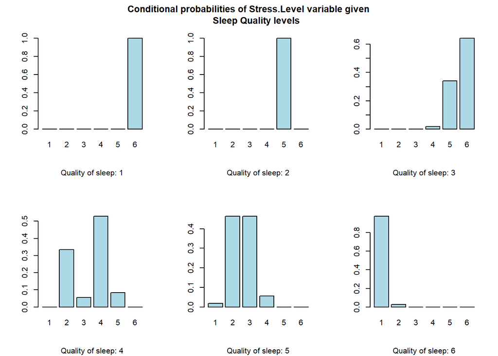

```r
par(mfrow = c(2, 3))
for (i in 1:6) barplot(nB$tables$Stress.Level[i, ], col = 'lightblue',
                       sub = paste('Quality of sleep:', i))
title('Conditional probabilities of Stress.Level variable given
      Sleep Quality levels', outer = T, line = -2.5)
```

As we said, for continuous predictors, we will have normal distributions with class-specific means and variances.

Before going on with the analysis, there is another thing we want to do: since the test error seems too good to be true, we want to assess if the model really is this accurate on test observations, using K-folds Cross-Validation. As for the Validation Set approach, this technique gives us a *direct* estimate of the test error too. It works as follows:

1. Divide data into K parts (folds);
2. For each $k = 1, ..., K$:
   1. train the model on all but the $k$-th part;
   2. estimate the test error using the $k$-th part observations.
3. Combine the results obtained for each fold using:

$$CV_K = \frac{1}{n} \sum_{k = 1}^K n_k MSE_k \text{, where } MSE_k =
\frac{1}{n_k} \sum_{i \in C_k} \mathbb{1}_{\{y_i \neq \hat{y}_i\}},$$
$n_k$ is the number of observations in fold $k$ and $C_k$ is the set of indices for observations in part $k$.

```r
K = 10
folds <- sample(rep(1:K, length = nrow(sleep)))
cv.err <- rep(NA, 10)
names(cv.err) <- 1:10

for (i in 1:K) {
    nB <- naiveBayes(Quality.of.Sleep ~ ., data = sleep, subset = folds != i)
    nB.pred <- predict(nB, newdata = sleep[folds == i, ])
    cv.err[i] <- mean(nB.pred != sleep[folds == i, 5])
}
cv.err.final <- mean(cv.err)
cv.err.final
```

```
## [1] 0.03214794
```

So this time we got a $3.21\%$ approximate test error, which is slightly higher than the one obtained using the validation set, but still very good. However, there is a problem: naive Bayes gave us a good model for predicting the sleep quality given all the other variables, but *understanding which variables are more important in the determination of the estimated class is tricky*. Also, with naive Bayes we don’t construct a model which is easily interpretable. Finally, we suspect that the model is biased away from classes $l = 1, 2$ of the response: this is because we have considerably less observations for these two, compared to how many we have for the other four classes.

For these reasons, we now try to use classification trees: these are also good predictors when combined together (bagging, random forests, boosting) but more importantly they also make possible to understand the most important variables in the determination of the final class.

### Classification Trees approach

Trees works by partitioning the predictors space in different (non-overlapping) regions, using critical points in which the space is splitted. Then, for each region, data in that region are used to generate a prediction, common to all the data points that will fall into.  
The tree building process can be divided into two main steps:

1. Divide the space spanned by the predictors into $J$ distinct and non-overlapping regions;
2. For each region, generate a prediction, which will be assigned to all the data points that will fall in that specific region.

In particular, the first point aims to minimize the following quantity:

$$RSS = \sum_{j = 1}^J \sum_{i : \mathbf{x}_i \in R_j}
\frac{\mathbb{1}_{\{y_i \neq \hat{y}_i\}}}{n_j}$$
where $R_j$ is the $j$-th region, $n_j$ is the number of observations in that region and $\hat{y}_i$ is the prediction for observations that fall into $R_j$; in particular, for classification, the common prediction for each region is given by the most commonly occurring class in that region. To minimize the above, the algorithm proceed by applying two techniques: Recursive Binary Splitting (to divide the predictors space into regions) and Cost Complexity Pruning (to prune the built tree in order to reduce variance and avoid overfitting).

The first thing we do, is to begin from a single tree. We will use again the validation set approach to evaluate the quality of predictions.

```r
set.seed(3)
train.index <- sample(1:nrow(sleep), nrow(sleep)/2)
#Fitting
sleep.tree <- tree(Quality.of.Sleep ~ ., sleep, subset = train.index)
summary(sleep.tree)
```

```
##
## Classification tree:
## tree(formula = Quality.of.Sleep ~ ., data = sleep, subset = train.index)
## Variables actually used in tree construction:
## [1] "Stress.Level"   "Sleep.Duration" "Occupation"     "Blood.Pressure"
## Number of terminal nodes:  7
## Residual mean deviance:  0.2178 = 39.21 / 180
## Misclassification error rate: 0.04813 = 9 / 187
```

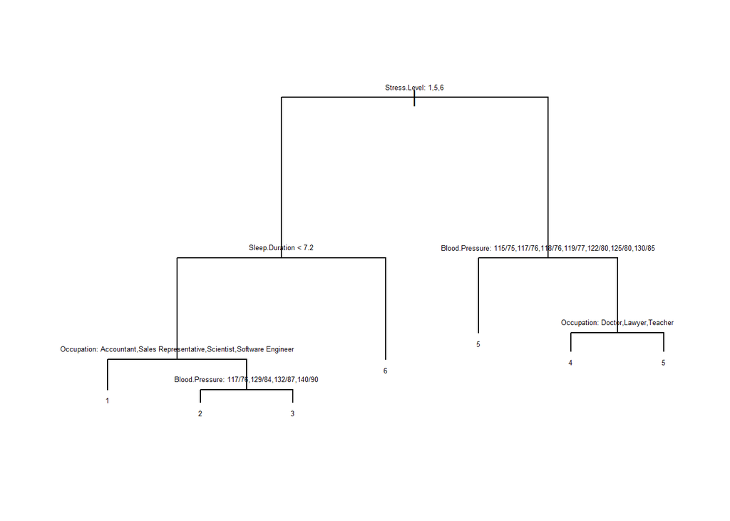

```r
#Plotting
plot(sleep.tree)
text(sleep.tree, pretty = 0, cex = .4)
```

We see from the plot that the most important variables for predicting **Quality.of.Sleep** seem to be: **Stress.Level**, **Sleep.Duration**, **Blood.Pressure** and **Occupation**, in this order.  
Before proceeding with the validation on the test set, we check if pruning the tree has some positive effects on the mis-classification error rate.

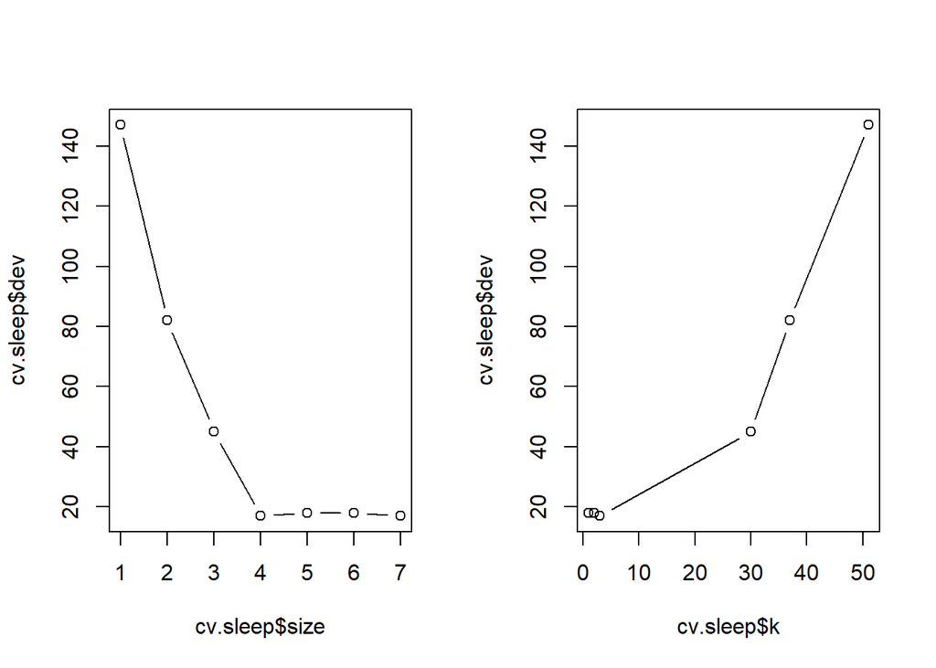

```r
cv.sleep <- cv.tree(sleep.tree, FUN = prune.misclass)
par(mfrow = c(1, 2))
plot(cv.sleep$size, cv.sleep$dev, 'b')
plot(cv.sleep$k, cv.sleep$dev, 'b')
```

The plot on the left suggests that trees with $4$ or more terminal nodes deliver basically the same performances, thus by the parsimony principle, we prefer the simpler tree possible among these similar-performing trees, which is given by $J = 4$, $J$ being the total number of terminal nodes.

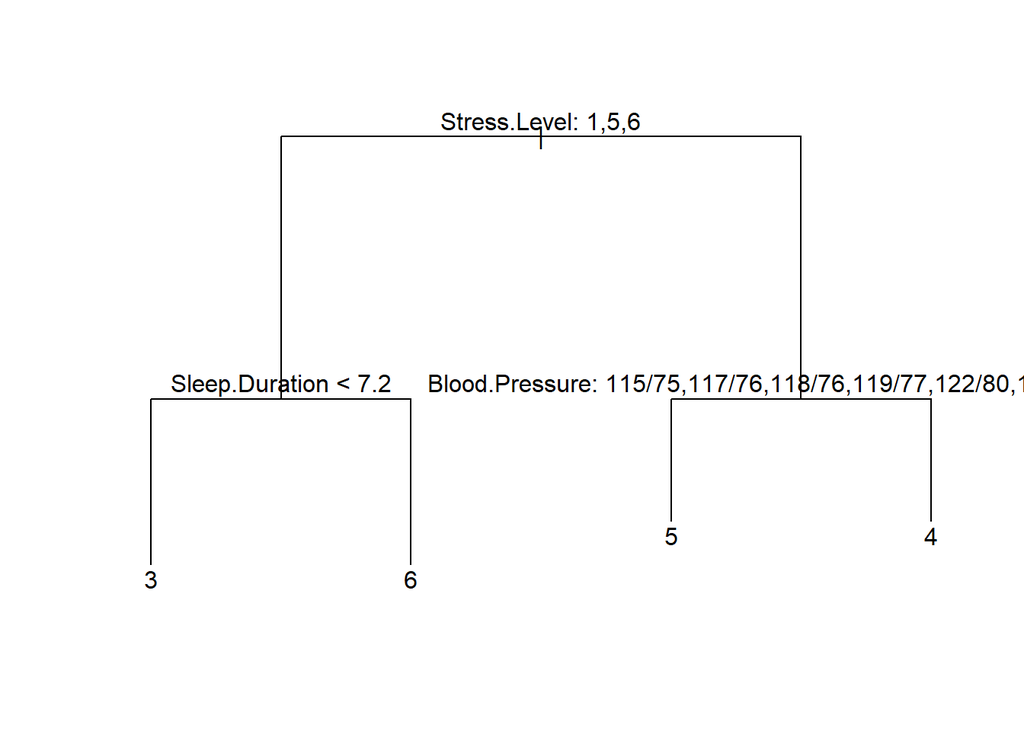

```r
sleep.pruned <- prune.misclass(sleep.tree, best = 4)
plot(sleep.pruned)
text(sleep.pruned, pretty = 0)
```

However from the plot we notice there is a problem: now the tree can only predict classes $3, 4, 5, 6$ leaving out classes $1, 2$. We suspect that this will negatively impact the validation set error rate:

```r
#Non-pruned tree
tree.preds <- predict(sleep.tree, sleep[-train.index, ], 'class')
table(tree.preds, sleep[-train.index, 5])
```

```
##
## tree.preds  1  2  3  4  5  6
##          1  1  0  0  3  0  0
##          2  0  2  0  0  0  0
##          3  0  2 49  1  0  0
##          4  1  0  0 35  0  0
##          5  0  0  3  2 54  1
##          6  0  0  0  0  1 32
```

```r
mean(tree.preds != sleep[-train.index, 5])
```

```
## [1] 0.07486631
```

```r
#Pruned tree at J = 4 terminal nodes
pred.pruned <- predict(sleep.pruned, sleep[-train.index, ], 'class')
table(pred.pruned, sleep[-train.index, 5])
```

```
##
## pred.pruned  1  2  3  4  5  6
##           1  0  0  0  0  0  0
##           2  0  0  0  0  0  0
##           3  2  4 49  4  0  0
##           4  0  0  1 35  2  1
##           5  0  0  2  2 52  0
##           6  0  0  0  0  1 32
```

```r
mean(pred.pruned != sleep[-train.index, 5])
```

```
## [1] 0.1016043
```

Indeed, we were right. This issue is caused from the fact that we have much less observations for those **Quality.of.Sleep** classes. Thus, even if cross-validation selected as best tree the pruned one, then it becomes too simple, and we lose the ability to distinguish among some less-frequent classes (recall the bar plot for **Quality.of.Sleep**), leading to a higher classification error on the test set. Hence, we can say that, for classification purposes, it is better to use the non-pruned tree, however, we also have to say that both these trees keep the same predictors to determine the class, with the exception of **Occupation**, not present in the simpler tree.  
Now we proceed our analysis by merging different trees, with the hope to improve prediction performances at the cost of some loss of interpretability.

#### Bagging

This is a technique that allows us to combine multiple trees predictions into one, to get more accurate results (reduced variance), but also a less interpretable model.

The reason why it works is because of the following result: for a sample $Z_1, ..., Z_n$ of observations such that $\text{Var}[Z_i] = \sigma^2$ and $\text{Cor}(Z_i, Z_j) = \rho$, it holds that $\text{Var}[\bar{Z}] = \frac{\sigma^2(1 - \rho)}{n} + \sigma^2 \rho$. So, averaging over observations reduces the variance. In our context, we can think of each random variable $Z_i$ corresponding to $\hat{f_i(\mathbf{x})}$, which is a single estimated tree; then, averaging them we get the bagged result, which will be a more precise estimate, according to what we have just said. In practice, to do that, we need $B$ different samples of size $n$ from the population, and with each one we estimate one tree. However, since sampling from the population is not possible, what we do is to generate $B$ bootstrap samples, build the tree on each of them and then combine the results predicted by each tree; in the case of classification trees, the combined result is the most predicted response class.

We have to use the *randomForest()* function from the homonymous library. This function can perform both bagging and random forests depending on how we set the parameter *mtry*: since the only difference in the two techniques is that in random forest we pick $m < p$ random predictors on which we search the best split, by setting $m = p$ we get bagging.

```r
bag.sleep <- randomForest(Quality.of.Sleep ~ ., sleep, subset = train.index, mtry = 11,
                          importance = TRUE)
bag.sleep
```

```
##
## Call:
##  randomForest(formula = Quality.of.Sleep ~ ., data = sleep, mtry = 11,      importance = TRUE, subset = train.index)
##                Type of random forest: classification
##                      Number of trees: 500
## No. of variables tried at each split: 11
##
##         OOB estimate of  error rate: 3.74%
## Confusion matrix:
##   1 2  3  4  5  6 class.error
## 1 2 0  1  0  0  0  0.33333333
## 2 0 2  1  0  0  0  0.33333333
## 3 0 1 50  1  1  0  0.05660377
## 4 0 0  0 34  2  0  0.05555556
## 5 0 0  0  0 54  0  0.00000000
## 6 0 0  0  0  0 38  0.00000000
```

We can see that the Out of Bag (OOB) error has been reported. This is an approximation of the test error computed using the fact that in each bootstrap sample, about $1/3$ of the original observations don’t appear in it (OOB observations). Thus, we can test the tree performances by using as test observations the OOB ones for that specific tree and then use these to compute an approximation of the test error. Here, the function did exactly that.

We see that the out-of-bag error is similar to naive Bayes, which is good. The performance on the validation set is:

```r
bag.pred <- predict(bag.sleep, sleep[-train.index, ])
table(bag.pred, sleep[-train.index, 5])
```

```
##
## bag.pred  1  2  3  4  5  6
##        1  2  0  0  0  0  0
##        2  0  2  0  0  0  0
##        3  0  2 50  1  0  0
##        4  0  0  0 38  1  0
##        5  0  0  2  2 54  0
##        6  0  0  0  0  0 33
```

```r
mean(bag.pred != sleep[-train.index, 5])
```

```
## [1] 0.04278075
```

Which is better than the single classification tree and very similar to naive Bayes.  
Even if we lost interpretability, we can anyway determine which variables are more important for the final classification of each observation:

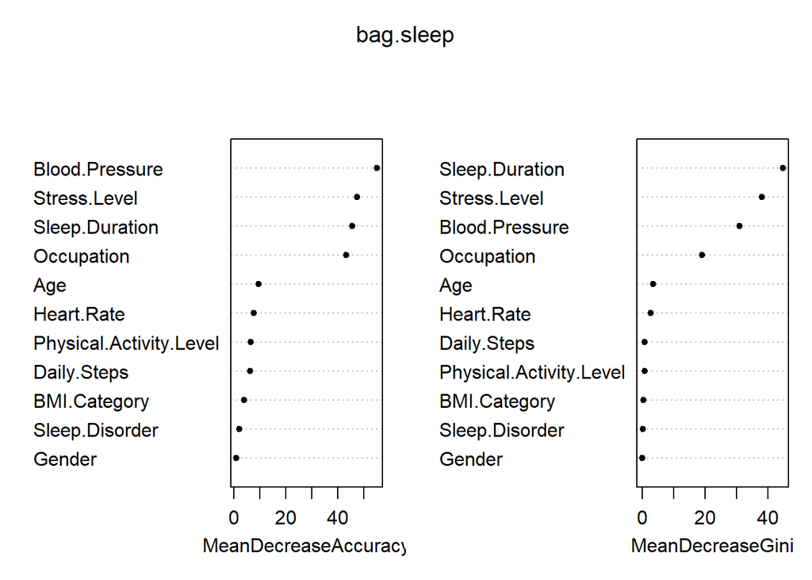

```r
varImpPlot(bag.sleep, pch = 20)
```

Again, we see that **Sleep.Duration**, **Blood.Pressure**, **Occupation** and **Stress.Level** are by far the most important variables in the determination of the predicted class.

#### Random Forests

As we anticipated above, random forests works more or less as bagging, with the only difference being that, when we are building the trees and we have to do a split in the predictors space, bagging can look for the best split among all the $p$ predictors, while random forests can only look among a random subset $m < p$ of the predictors. This is done in order to reduce the correlation $\rho(\mathbf{x})$ among trees and hence reduce variance even more, at least theoretically, according to the above result about $\text{Var}[\bar{Z}]$.

```r
rf.sleep <- randomForest(Quality.of.Sleep ~ ., sleep, subset = train.index, mtry = 3,
                          importance = TRUE)
rf.sleep
```

```
##
## Call:
##  randomForest(formula = Quality.of.Sleep ~ ., data = sleep, mtry = 3,      importance = TRUE, subset = train.index)
##                Type of random forest: classification
##                      Number of trees: 500
## No. of variables tried at each split: 3
##
##         OOB estimate of  error rate: 3.74%
## Confusion matrix:
##   1 2  3  4  5  6 class.error
## 1 1 0  2  0  0  0  0.66666667
## 2 0 2  1  0  0  0  0.33333333
## 3 0 1 50  1  1  0  0.05660377
## 4 0 0  0 35  1  0  0.02777778
## 5 0 0  0  0 54  0  0.00000000
## 6 0 0  0  0  0 38  0.00000000
```

```r
rf.pred <- predict(rf.sleep, sleep[-train.index, ])
table(rf.pred, sleep[-train.index, 5])
```

```
##
## rf.pred  1  2  3  4  5  6
##       1  2  0  0  0  0  0
##       2  0  2  0  0  0  0
##       3  0  2 52  1  0  0
##       4  0  0  0 37  0  0
##       5  0  0  0  3 55  0
##       6  0  0  0  0  0 33
```

```r
mean(rf.pred != sleep[-train.index, 5])
```

```
## [1] 0.03208556
```

Which is lower than bagging, hence it seems that random forests perform slightly better.  
We check again variable importance:

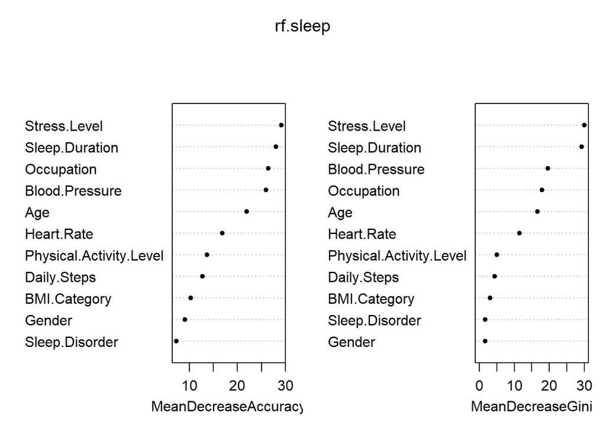

```r
varImpPlot(rf.sleep, pch = 20)
```

Which are again the same.

#### Boosting

This is different from bagging and random forests, since it does not build different trees ‘in parallel’, but, sequentially, uses the predictions made from a starting tree to learn from its errors. In particular, suppose we fit a tree $T$ that predicts $\hat{f}(\mathbf{x}_1), ..., \hat{f}(\mathbf{x}_n)$ for $y_1, ..., y_n$. Then, what we do, is to train another tree $T_1$ such that it predicts on a new set of responses (this is technically a re-weighted version of the training data) given by: $y_1 - \hat{f}(\mathbf{x}_1), ..., y_n - \hat{f}(\mathbf{x}_n)$. We do this iteratively for an arbitrary number of steps and then sum the predictions of $T, T_1, ...$ to get the overall prediction of $y_i$.

To do that in R, we proceed as follows:

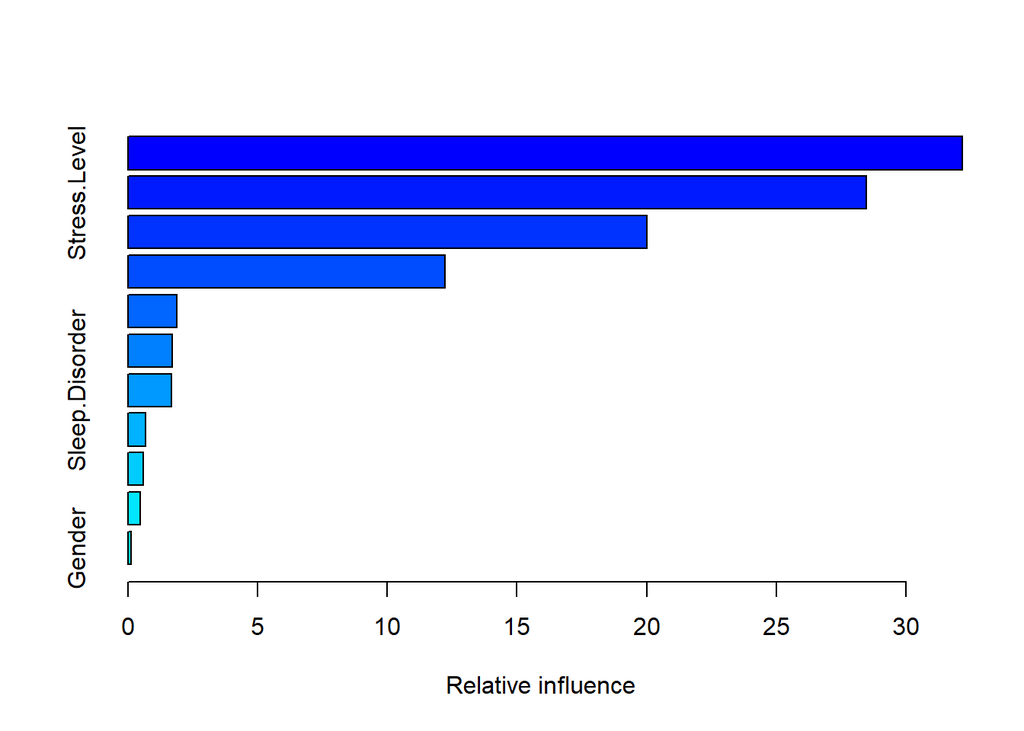

```
##                                             var    rel.inf
## Sleep.Duration                   Sleep.Duration 32.1722672
## Stress.Level                       Stress.Level 28.4731943
## Blood.Pressure                   Blood.Pressure 20.0261368
## Occupation                           Occupation 12.2284527
## Age                                         Age  1.8702531
## Daily.Steps                         Daily.Steps  1.7153335
## Sleep.Disorder                   Sleep.Disorder  1.6861322
## Physical.Activity.Level Physical.Activity.Level  0.6706806
## Heart.Rate                           Heart.Rate  0.5831109
## BMI.Category                       BMI.Category  0.4648239
## Gender                                   Gender  0.1096148
```

```r
boos.sleep <- gbm(Quality.of.Sleep ~ ., data = sleep[train.index, ],
                  distribution = 'multinomial', n.trees = 5000, interaction.depth = 3)
summary(boos.sleep)
```

We discuss a moment the parameters we gave as input:

- *distribution* is set to *multinomial* because we are dealing with a predictors with more than $2$ classes;
- *n.trees* is the number of trees to estimate to then give collectively the output class;
- *interaction.depth* is the maximum depth of each tree.

The *summary()* function in this case plots also the importance of the variables; again, we see that the most important ones are the same of bagging, random forest and of the single classification tree.  
We now estimate the test error using the validation set. This time, we have to do an extra step, since the *predict()* method of the *gbm* class only outputs either log-odds or probabilities, for each class at each observation. Hence, we set as predicted class, the one with the highest class probability.

```r
probs <- predict(boos.sleep, sleep[-train.index, ], n.trees = 5000, type = 'response')
boos.pred <- apply(probs, 1, which.max)

table(boos.pred, sleep[-train.index, 5])
```

```
##
## boos.pred  1  2  3  4  5  6
##         1  2  0  0  0  0  0
##         2  0  3  0  0  0  0
##         3  0  1 52  4  0  0
##         4  0  0  0 37  0  0
##         5  0  0  0  0 55  0
##         6  0  0  0  0  0 33
```

```r
mean(boos.pred != sleep[-train.index, 5])
```

```
## [1] 0.02673797
```

Which is lower than the one obtained with any other technique involving trees and it is very similar to the error obtained with the naive Bayes approach.

We now set ourselves as goal to *build a model which must be able to predict the sleep duration of an individual, given all the other predictors* and to understand *which variables are the most important for this task*. To do this, we will try if the assumption of a simple linear model is good enough.

### A classical Multiple Linear regression

Recall that we assume a model of the form:

$$y_i = \beta_0 + \beta_1x_{i1} +, ..., + \beta_px_{ip} + \epsilon_i,
\text{ for } i = 1, ..., n$$
and we estimate the coefficients using the Least Squares approach, where we have to minimize the sum of squared residuals:

$$\sum_{i = 1}^n (y_i - \mathbf{x}_i^T\hat{\beta})^2 = (\mathbf{y} -
\mathbf{X\hat{\beta}})^T(\mathbf{y} - \mathbf{X\hat{\beta}})$$
where $\mathbf{y} = (y_1, ..., y_n)$, $\mathbf{X} \in \mathbb{R}^{n \times p}$ and $\beta = (\beta_0, ..., \beta_p)$. Once we have done that, we predict using $\hat{\mathbf{y}} = \mathbf{X\hat{\beta}}$.

We begin by regressing **Sleep.Duration** against all the other variables. We again split the observations in a training and a validation set.

```r
set.seed(21)
train.index <- sample(1:nrow(sleep), nrow(sleep)/2)
lm.dur <- lm(Sleep.Duration ~ ., data = sleep, subset = train.index)
summary(lm.dur)
```

```
##
## Call:
## lm(formula = Sleep.Duration ~ ., data = sleep, subset = train.index)
##
## Residuals:
##      Min       1Q   Median       3Q      Max
## -0.15278 -0.04444  0.00000  0.03721  0.16155
##
## Coefficients: (12 not defined because of singularities)
##                                  Estimate Std. Error t value Pr(>|t|)
## (Intercept)                     1.393e+01  1.918e+00   7.262 1.85e-11 ***
## GenderMale                     -9.807e-01  2.676e-01  -3.665 0.000342 ***
## Age                            -3.951e-02  7.713e-03  -5.122 9.03e-07 ***
## OccupationDoctor               -5.111e-01  4.746e-01  -1.077 0.283282
## OccupationEngineer             -6.857e-01  3.557e-01  -1.928 0.055761 .
## OccupationLawyer               -8.061e-01  3.635e-01  -2.218 0.028046 *
## OccupationNurse                -7.421e-01  9.591e-02  -7.737 1.31e-12 ***
## OccupationSales Representative -2.137e+00  3.456e-01  -6.184 5.52e-09 ***
## OccupationSalesperson           4.172e-01  7.576e-01   0.551 0.582692
## OccupationScientist            -9.206e-01  1.413e-01  -6.516 1.00e-09 ***
## OccupationSoftware Engineer    -1.565e-01  1.976e-01  -0.792 0.429735
## OccupationTeacher              -4.850e-03  5.640e-02  -0.086 0.931581
## Quality.of.Sleep2              -9.618e-01  2.193e-01  -4.386 2.15e-05 ***
## Quality.of.Sleep3              -1.737e+00  5.663e-01  -3.068 0.002555 **
## Quality.of.Sleep4              -1.253e+00  2.762e-01  -4.537 1.15e-05 ***
## Quality.of.Sleep5              -5.190e-01  1.576e-01  -3.293 0.001231 **
## Quality.of.Sleep6                      NA         NA      NA       NA
## Physical.Activity.Level         2.421e-02  1.791e-03  13.516  < 2e-16 ***
## Stress.Level2                  -1.090e+00  2.333e-01  -4.671 6.54e-06 ***
## Stress.Level3                   7.269e-01  3.395e-01   2.141 0.033869 *
## Stress.Level4                  -7.388e-03  1.868e-01  -0.040 0.968496
## Stress.Level5                          NA         NA      NA       NA
## Stress.Level6                  -2.119e-01  4.273e-01  -0.496 0.620655
## BMI.CategoryObese               1.508e+00  5.968e-01   2.527 0.012523 *
## BMI.CategoryOverweight          5.403e-01  3.540e-01   1.526 0.129070
## Blood.Pressure115/78           -1.189e+00  2.619e-01  -4.539 1.14e-05 ***
## Blood.Pressure118/76           -2.002e-02  2.829e-01  -0.071 0.943672
## Blood.Pressure119/77           -4.471e-01  1.471e-01  -3.040 0.002784 **
## Blood.Pressure120/80            1.317e+00  1.183e-01  11.131  < 2e-16 ***
## Blood.Pressure125/80            1.290e+00  1.543e-01   8.361 3.68e-14 ***
```

[output cut: 8 more lines]

```
## Blood.Pressure135/90                   NA         NA      NA       NA
## Blood.Pressure139/91                   NA         NA      NA       NA
## Blood.Pressure140/90                   NA         NA      NA       NA
## Blood.Pressure140/95                   NA         NA      NA       NA
## Blood.Pressure142/92                   NA         NA      NA       NA
## Heart.Rate                     -6.533e-02  2.863e-02  -2.282 0.023881 *
## Daily.Steps                    -1.066e-04  2.144e-05  -4.969 1.79e-06 ***
## Sleep.DisorderNone              4.140e-02  3.582e-02   1.156 0.249674
## Sleep.DisorderSleep Apnea       4.651e-02  5.244e-02   0.887 0.376544
## ---
## Signif. codes:  0 '***' 0.001 '**' 0.01 '*' 0.05 '.' 0.1 ' ' 1
##
## Residual standard error: 0.06898 on 152 degrees of freedom
## Multiple R-squared:  0.9937, Adjusted R-squared:  0.9923
## F-statistic: 710.5 on 34 and 152 DF,  p-value: < 2.2e-16
```

Even if the results of the estimation seems pretty good, since a lot of the coefficients are statistically significant, we have a big issue: for some of the variables, like **Stress.Level** or **Blood.Pressure** there are no data for some of the categories; for example, in the training data we have no observations for a stress level of $5$. This is a problem because then, when we try to estimate predictions for the response using the test set, if these missing observations are instead present in it, we won’t be able to make predictions, since in the estimation of the coefficients there will be missing ones in correspondence of the missing data.  
A solution could be of dropping the problematic variables, however we don’t want to do that because these can be important to get accurate predictions, so the trade-off is to combine different levels of these categorical observations into one, like this:

```r
Sleep.Qual.simp <- ifelse(as.numeric(sleep$Quality.of.Sleep) <= 3, 'Bad', 'Good')
Stress.Lev.simp <- ifelse(as.numeric(sleep$Stress.Level) <= 2, 'Low', ifelse(as.numeric(sleep$Stress.Level) <= 4, 'High', 'Very High'))
```

In this way, it is more likely to get observations for each category both in the training and in the validation set, without losing too much generality.  
For the **Blood.Pressure** variable, creating dummies is a bit more involved because of the way that the observations for this predictor are specified:

```r
blood.p.chr <- as.character(sleep$Blood.Pressure)
splitted <- rep(0, 2)
Blood.Pressure.simp <- rep(NA, nrow(sleep))

for (i in 1:nrow(sleep)) {

    splitted <- strsplit(blood.p.chr[i], '/')[[1]]
    splitted <- as.numeric((splitted))

    if (splitted[1] < 120 & splitted[2] < 80) {
        Blood.Pressure.simp[i] <- 'Normal'}
    else if (splitted[1] <= 129 & splitted[2] <= 80) {
        Blood.Pressure.simp[i] <- 'Elevated'}
    else {
        Blood.Pressure.simp[i] <- 'High'}
}
```

Even if it didn’t give us problems, we also want to categorize differently the **Occupation** variable because there are some classes with very few levels (for example, in the whole data set, there is only one manager). The subdivision we chose is STEM vs. non-STEM jobs, where STEM is the acronym of ‘science, technology, engineering and mathematics’, so it is used to distinguish jobs in that sectors from others.

```r
Occupation.simp <- ifelse(as.character(sleep$Occupation) == 'Engineer' | as.character(sleep$Occupation) == 'Scientist' | as.character(sleep$Occupation) == 'Software Engineer', 'STEM', 'non-STEM')
```

Now we are only left to put these variables in the data set and remove the old ones:

```r
sleep <- sleep[, -c(3, 5, 7, 9)]
sleep <- cbind(sleep, Sleep.Qual.simp, Stress.Lev.simp, Blood.Pressure.simp, Occupation.simp)

#Convert the new variables into factor variables
sleep$Sleep.Qual.simp <- factor(sleep$Sleep.Qual.simp)
sleep$Stress.Lev.simp <- factor(sleep$Stress.Lev.simp)
sleep$Blood.Pressure.simp <- factor(sleep$Blood.Pressure.simp)
sleep$Occupation.simp <- factor(sleep$Occupation.simp)
```

Now we can finally work on this data set. We again try a multiple Linear regression:

```r
lm.dur <- lm(Sleep.Duration ~ ., data = sleep, subset = train.index)
summary(lm.dur)
```

```
##
## Call:
## lm(formula = Sleep.Duration ~ ., data = sleep, subset = train.index)
##
## Residuals:
##      Min       1Q   Median       3Q      Max
## -0.79468 -0.14324  0.01735  0.12663  0.77098
##
## Coefficients:
##                             Estimate Std. Error t value Pr(>|t|)
## (Intercept)                1.261e-01  1.465e+00   0.086 0.931513
## GenderMale                 6.571e-01  8.780e-02   7.484 3.63e-12 ***
## Age                        7.073e-02  4.639e-03  15.249  < 2e-16 ***
## Physical.Activity.Level    1.743e-03  2.305e-03   0.756 0.450697
## BMI.CategoryObese         -1.525e+00  3.236e-01  -4.710 5.09e-06 ***
## BMI.CategoryOverweight    -3.513e-01  1.070e-01  -3.283 0.001244 **
## Heart.Rate                 6.300e-02  1.901e-02   3.314 0.001123 **
## Daily.Steps               -6.417e-05  2.807e-05  -2.286 0.023473 *
## Sleep.DisorderNone        -7.346e-02  8.746e-02  -0.840 0.402123
## Sleep.DisorderSleep Apnea  1.909e-01  9.017e-02   2.117 0.035709 *
## Sleep.Qual.simpGood        6.748e-01  2.647e-01   2.549 0.011677 *
## Stress.Lev.simpLow         2.253e-02  1.135e-01   0.199 0.842819
## Stress.Lev.simpVery High  -8.289e-01  2.238e-01  -3.703 0.000287 ***
## Blood.Pressure.simpHigh   -6.868e-01  7.312e-02  -9.393  < 2e-16 ***
## Blood.Pressure.simpNormal -1.529e-01  9.366e-02  -1.633 0.104339
## Occupation.simpSTEM        3.485e-03  7.294e-02   0.048 0.961951
## ---
## Signif. codes:  0 '***' 0.001 '**' 0.01 '*' 0.05 '.' 0.1 ' ' 1
##
## Residual standard error: 0.2483 on 171 degrees of freedom
## Multiple R-squared:  0.9089, Adjusted R-squared:  0.9009
## F-statistic: 113.7 on 15 and 171 DF,  p-value: < 2.2e-16
```

We can see that now the issue is solved. From the above summary, we can see that the statistically significant variables are **Gender**, **Age**, **BMI.Category**, **Heart.Rate**, **Daily.Steps**, **Sleep.Disorder**, **Sleep.Quality**, **Stress.Level** and **Blood.Pressure**.

Before proceeding we check with some diagnostic plots if the linear assumption between response and predictors is reasonable:

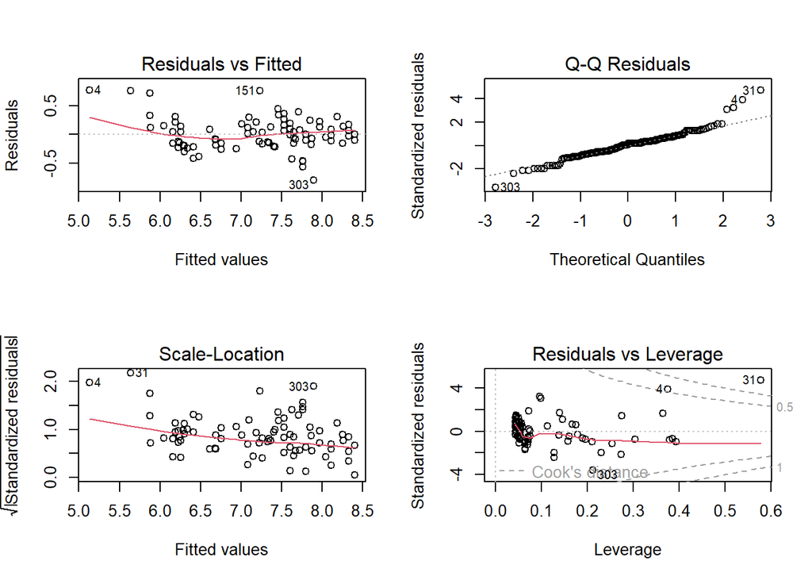

```r
par(mfrow = c(2, 2))
plot(lm.dur)
```

We can see that the assumption holds by looking at the upper-left corner plot: there is no discernible pattern, the relation seems linear; it is possible that the red line is influenced in some areas from some outliers present in the data set. Moreover, the data distribution can also be assumed to be normal, by looking at the Q-Q plot on the upper-right corner.  
Hence we can proceed by predicting on the validation set and computing the MSE:

```r
dur.pred <- predict(lm.dur, sleep[-train.index, ])
mean((dur.pred - sleep[-train.index, 3])^2)
```

```
## [1] 0.1080693
```

So we got a mean-squared error of $0.1081$, which means that our predictions have on average an error of $\pm \sqrt{0.1081} \sim 0.329$ in terms of **Sleep.Duration**, which is not bad.

### Variable Selection via Best Subset Selection

Since we don’t have too many predictors, we can find the global maximum in terms of most accurate model, by looking between all the possible $2^p$ predictors, which in our case are, considering the dummy that will be generated for regressions, $2^{15} = 32768$ possible models. To do that, we use a procedure called Best Subset Selection, which fits, for every possible model dimension $d$ (i.e., with one predictor, two predictors and so on) all the possible models and choose the best among them using metrics like $R^2$ or $RSS$; then, among the best models for each dimension $\mathcal{M}_0, ..., \mathcal{M}_p$, we choose the best using either some indirect approximations of the test error (adjusted-$R^2$, $C_p$, AIC, BIC) or direct estimate of the test error (via Validation Set or Cross-Validation). Notice that we can use the $R^2$ to select among different models with the same number of predictors, but we cannot use it to select among models with different number of predictors, since this metric increases monotonically as we add them. Thus, we use its adjusted version for this last task, which penalizes the metric when we add more predictors to the model.  
We will try all these approaches to select the best model possible. We first try the selection without the validation set approach, but using some indirect measures that estimate the test error.

#### Selection via Indirect Test Error Measures

```r
bss <- regsubsets(Sleep.Duration ~., data = sleep, nvmax = 15)
sum.bss <- summary(bss)
sum.bss
```

```
## Subset selection object
## Call: regsubsets.formula(Sleep.Duration ~ ., data = sleep, nvmax = 15)
## 15 Variables  (and intercept)
##                           Forced in Forced out
## GenderMale                    FALSE      FALSE
## Age                           FALSE      FALSE
## Physical.Activity.Level       FALSE      FALSE
## BMI.CategoryObese             FALSE      FALSE
## BMI.CategoryOverweight        FALSE      FALSE
## Heart.Rate                    FALSE      FALSE
## Daily.Steps                   FALSE      FALSE
## Sleep.DisorderNone            FALSE      FALSE
## Sleep.DisorderSleep Apnea     FALSE      FALSE
## Sleep.Qual.simpGood           FALSE      FALSE
## Stress.Lev.simpLow            FALSE      FALSE
```

[output cut: 86 more lines]

Now, to choose among the best model for each number of predictors, we use the above mentioned metrics; in particular, we focus on adjusted-$R^2$ and $C_p$:

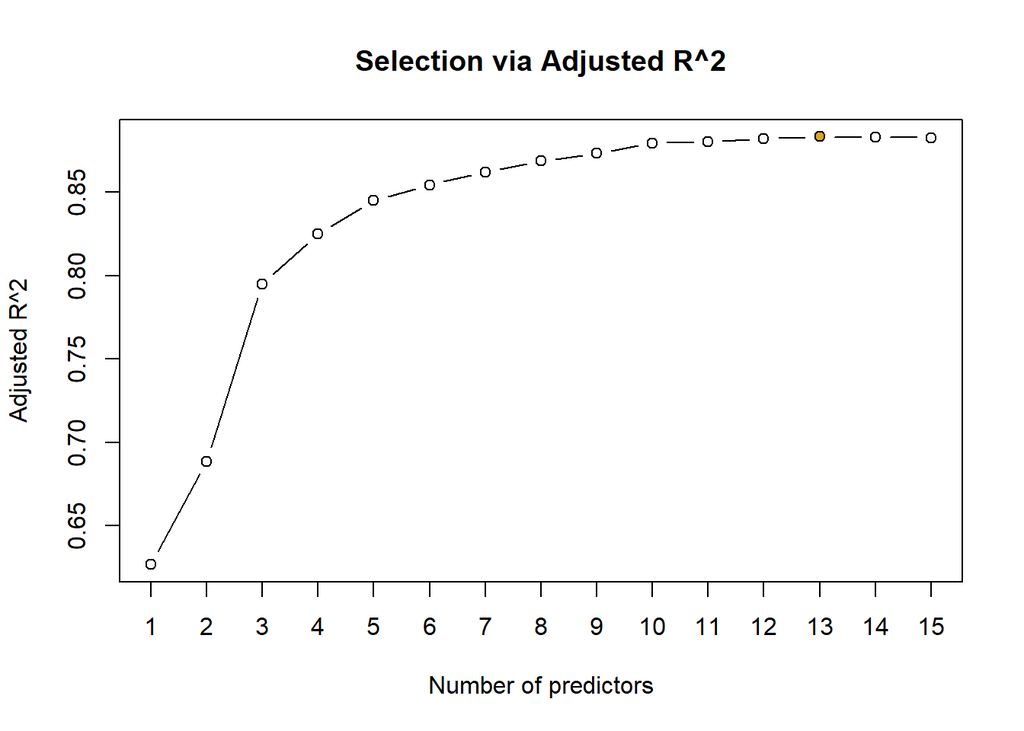

```r
par(mfrow = c(1, 1))
plot(sum.bss$adjr2, axes = FALSE, xlab = 'Number of predictors', ylab = 'Adjusted R^2', type = 'b', pch = 21, main = 'Selection via Adjusted R^2')
axis(1, at = 1:15)
axis(2)
box()
points(which.max(sum.bss$adjr2), sum.bss$adjr2[which.max(sum.bss$adjr2)], pch = 21, bg = 'goldenrod')
```

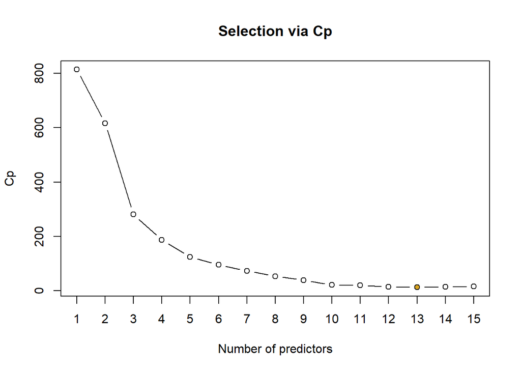

```r
plot(sum.bss$cp, axes = FALSE, xlab = 'Number of predictors', ylab = 'Cp', type = 'b', pch = 21, main = 'Selection via Cp')
axis(1, at = 1:15)
axis(2)
box()
points(which.min(sum.bss$cp), sum.bss$cp[which.min(sum.bss$cp)], pch = 21, bg = 'goldenrod')
```

Hence using best subset selection, we find out that the best model is the one with $p = 13$ predictors, according to both adjusted-$R^2$ and $C_p$, which are:

```r
coef(bss, 13)
```

```
##               (Intercept)                GenderMale                       Age
##              2.224201e+00              4.512445e-01              6.098348e-02
##   Physical.Activity.Level         BMI.CategoryObese    BMI.CategoryOverweight
##              4.516218e-03             -1.034744e+00             -4.707039e-01
##                Heart.Rate               Daily.Steps        Sleep.DisorderNone
##              4.396325e-02             -8.950349e-05             -1.226971e-01
## Sleep.DisorderSleep Apnea       Sleep.Qual.simpGood  Stress.Lev.simpVery High
##              1.380058e-01              3.866781e-01             -9.482576e-01
##   Blood.Pressure.simpHigh Blood.Pressure.simpNormal
##             -5.431136e-01             -1.646436e-01
```

Notice that different coefficients are estimated on dummies generated from the same categorical variables: hence in reality the best model contains $p = 10$ variables.

#### Selection via Validation Set approach

Now we want to figure out which is the best model using the validation set approach. To do so, we split the data into training and test set, we apply Best Subset Selection by using only the training data and then we compute the approximate test error using only the validation set, for each model $\mathcal{M}_0, ..., \mathcal{M}_p$.

Before proceeding, we convert the factor variables in the original data frame into dummies; we do so because it will comes in handy after, when we will do predictions with the estimated models.

```r
sleep.mm <- model.matrix(Sleep.Duration ~ ., data = sleep)
sleep.mm <- data.frame(sleep.mm[, -1]) #from matrix to data frame and we remove intercept
sleep.mm$Sleep.Duration <- sleep$Sleep.Duration #add back the response
```

Now we can apply best subset selection:

```r
bss <- regsubsets(Sleep.Duration ~ ., data = sleep.mm[train.index, ], nvmax = 15)
sum.bss <- summary(bss)
sum.bss
```

```
## Subset selection object
## Call: regsubsets.formula(Sleep.Duration ~ ., data = sleep.mm[train.index,
##     ], nvmax = 15)
## 15 Variables  (and intercept)
##                           Forced in Forced out
## GenderMale                    FALSE      FALSE
## Age                           FALSE      FALSE
## Physical.Activity.Level       FALSE      FALSE
## BMI.CategoryObese             FALSE      FALSE
## BMI.CategoryOverweight        FALSE      FALSE
## Heart.Rate                    FALSE      FALSE
## Daily.Steps                   FALSE      FALSE
## Sleep.DisorderNone            FALSE      FALSE
## Sleep.DisorderSleep.Apnea     FALSE      FALSE
## Sleep.Qual.simpGood           FALSE      FALSE
```

[output cut: 87 more lines]

We need to estimate the test error on each best model for each model size. To do so, we create a small function to extract the model formula each time:

```r
get_formula <- function(model, i) {

    coeffs <- names(coef(model, i))[-1]
    coeffs <- paste0('`', coeffs, '`') #in order to avoid problems with spaced names
    coeffs <- paste('Sleep.Duration ~', paste(coeffs, collapse = ' + '))
    coeffs <- as.formula(coeffs)

    return(coeffs)
}
```

Now we use the function in the following loop and we store the test errors in a vector, which then we plot:

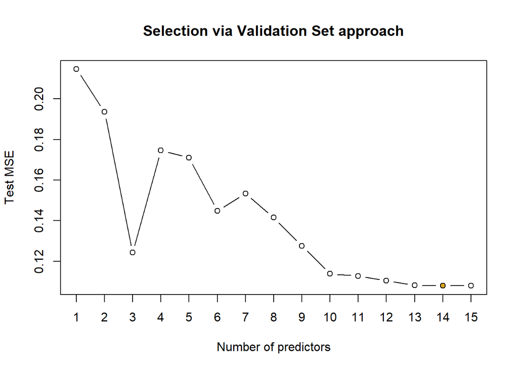

```r
test_err <- 0
for (i in 1:15) {
    form <- get_formula(bss, i)
    model <- lm(form, data = sleep.mm[train.index, ])
    pred.model <- predict(model, sleep.mm[-train.index, ])
    test_err[i] <- mean((pred.model - sleep.mm[-train.index, 16])^2)
}

#Plotting
plot(test_err, type = 'b', axes = FALSE, xlab = 'Number of predictors', ylab = 'Test MSE', pch = 21, main = 'Selection via Validation Set approach')
axis(1, at = 1:15)
axis(2)
box()
points(which.min(test_err), test_err[which.min(test_err)], pch = 21, bg = 'goldenrod')
```

So, we can see that using the validation set approach we again should select as best model the one with $p = 14$ predictors. Before showing which variables are involved, we re-fit the best model using the whole data set, to get more accurate estimates of the coefficients:

```r
bss <- regsubsets(Sleep.Duration ~ ., data = sleep.mm, nvmax = 15)
```

```r
coef(bss, 14)
```

```
##               (Intercept)                GenderMale                       Age
##              1.989092e+00              4.624961e-01              6.087534e-02
##   Physical.Activity.Level         BMI.CategoryObese    BMI.CategoryOverweight
##              4.307169e-03             -1.065048e+00             -4.778886e-01
##                Heart.Rate               Daily.Steps        Sleep.DisorderNone
##              4.678700e-02             -8.517034e-05             -1.223757e-01
## Sleep.DisorderSleep.Apnea       Sleep.Qual.simpGood        Stress.Lev.simpLow
##              1.319373e-01              3.919153e-01              3.520607e-02
##  Stress.Lev.simpVery.High   Blood.Pressure.simpHigh Blood.Pressure.simpNormal
##             -9.416519e-01             -5.339636e-01             -1.736019e-01
```

Again, since some variables are dummies of some originally categorical variables, in reality the best model selected has again $p = 10$ variables.

#### Selection via Cross-validation approach

Finally, to be even more sure of these results, we can estimate the test error by using the cross-validation approach. To do that, we must compute the test error for each model size $\mathcal{M}_0, ..., \mathcal{M}_p$ and on each one of the $K$ folds; in order to get relatively small bias and variance of the test approximations, a good choice is $K = 10$.

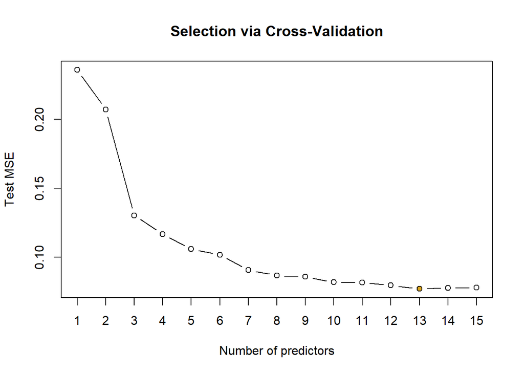

```r
#Computing test errors
K <- 10
err.matrix <- matrix(NA, K, 15)
sampler <- rep(1:10, length.out = nrow(sleep))
for (i in 1:10) {
    bss <- regsubsets(Sleep.Duration ~ ., data = sleep.mm[sampler != i, ], nvmax = 15)
    for (j in 1:15) {
        form <- get_formula(bss, j)
        model <- lm(form, data = sleep.mm[sampler != i, ])
        pred.model <- predict(model, sleep.mm[sampler == i, ])
        err.matrix[i, j] <- mean((pred.model - sleep.mm[sampler == i, 16])^2)
    }
}
cv_err <- apply(err.matrix, 2, mean)

#Plotting results
plot(cv_err, type = 'b', axes = FALSE, pch = 21, main = 'Selection via Cross-Validation', ylab = 'Test MSE', xlab = 'Number of predictors')
axis(1, at = 1:15)
axis(2)
box()
points(which.min(cv_err), cv_err[which.min(cv_err)], pch = 21, bg = 'goldenrod')
```

Here, the best model is the one with $p = 13$ predictors. We now estimate the best model with this number of predictors using all data, in order to get more precise coefficients estimates:

```r
bss <- regsubsets(Sleep.Duration ~ ., data = sleep.mm, nvmax = 15)
```

Finally, we can extract the model of interest:

```r
coef(bss, 13)
```

```
##               (Intercept)                GenderMale                       Age
##              2.224201e+00              4.512445e-01              6.098348e-02
##   Physical.Activity.Level         BMI.CategoryObese    BMI.CategoryOverweight
##              4.516218e-03             -1.034744e+00             -4.707039e-01
##                Heart.Rate               Daily.Steps        Sleep.DisorderNone
##              4.396325e-02             -8.950349e-05             -1.226971e-01
## Sleep.DisorderSleep.Apnea       Sleep.Qual.simpGood  Stress.Lev.simpVery.High
##              1.380058e-01              3.866781e-01             -9.482576e-01
##   Blood.Pressure.simpHigh Blood.Pressure.simpNormal
##             -5.431136e-01             -1.646436e-01
```

Again, the effective variables present in the model are $10$, since some of them are dummies of the same variable.

As we can see, most of the results we got make sense, apart for some predictors. However math doesn’t lie, and it tells us that this exact combination of predictors is the one that gives the most accurate predictions. Nevertheless, if our main goal is not exclusively prediction accuracy, but also trying to get some conclusions on how to sleep better and longer (which indeed is), we could also take into consideration some simpler models which have a lower prediction accuracy of this one, but which are more interpretable. To select this model in the most objective way possible, we can use the One-Standard-Error rule. Recall the above plot of CV errors for each model dimension: we compute the standard error of the lowest point in the curve and select the smallest model whose estimated CV error is within one standard error from the lowest point in the curve.

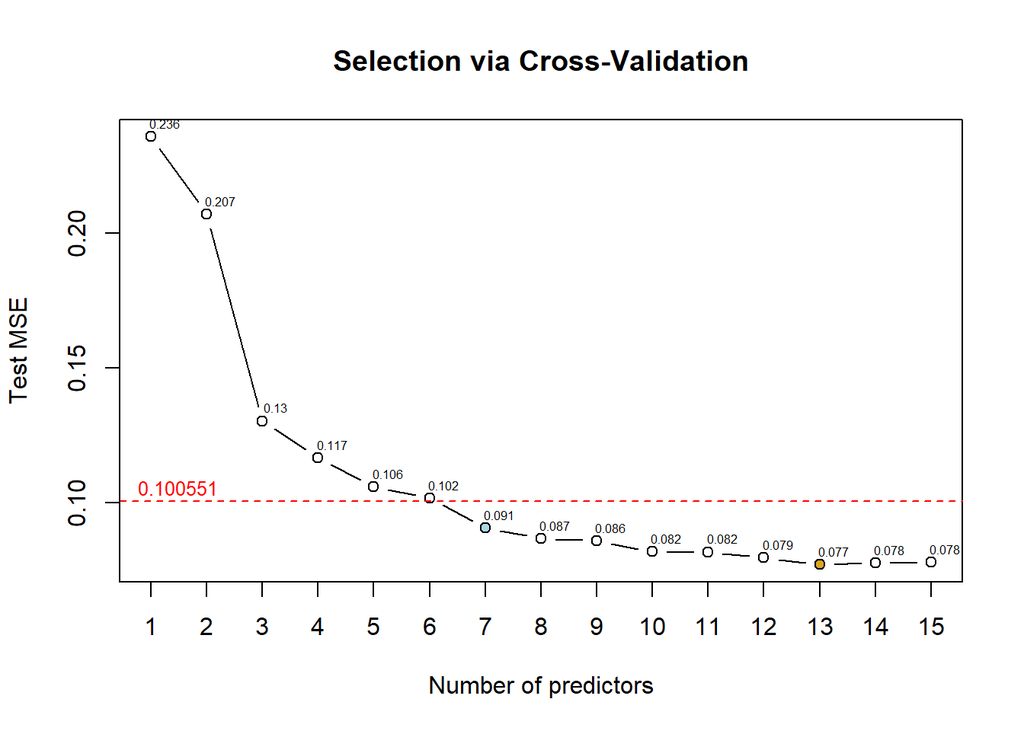

```r
sds <- apply(err.matrix, 2, sd)
threshold <- cv_err[13] + sds[13]

plot(cv_err, type = 'b', axes = FALSE, pch = 21, main = 'Selection via Cross-Validation', ylab = 'Test MSE', xlab = 'Number of predictors')
axis(1, at = 1:15)
axis(2)
box()
text(1:15 + .25, cv_err + 0.005, round(cv_err, 3), cex = .5)
points(which.min(cv_err), cv_err[which.min(cv_err)], pch = 21, bg = 'goldenrod')
points(7, cv_err[7], pch = 21, bg = 'lightblue')
abline(h = threshold, col = 'red', lty = 2)
text(1.5, threshold + .005, round(threshold, 6), cex = .8, col = 'red')
```

With this method, it turns out that the model of choice is the one with $p = 7$ variables, given by:

```r
coef(bss, 7)
```

```
##              (Intercept)               GenderMale                      Age
##               1.38384359               0.50256229               0.06964389
##        BMI.CategoryObese   BMI.CategoryOverweight               Heart.Rate
##              -0.61949464              -0.36840769               0.04912765
## Stress.Lev.simpVery.High  Blood.Pressure.simpHigh
##              -1.31483849              -0.51864800
```

Since there are two dummies of the same categorical variable, in reality the best model has $p = 6$ predictors. This is indeed more interpretable:

- **Gender**: males sleeps slightly more than women on average;
- **Age**: older people sleep longer;
- **Body Mass Index**: being in shape helps to sleep longer;
- **Heart Rate**: apparently, having a slightly higher heart rate helps to sleep a little longer;
- **Stress Level**: too much stress makes one sleep way less;
- **Blood Pressure**: if it is too high, then it negatively affects the sleep duration of an individual.

We can say that this model is pretty similar to the one with lower CV test error rate, however it is preferable since it is simpler and it does not cost us too much in terms of lost prediction accuracy.  
One remark we want to do is about the **Heart.Rate** variable: on the web page where we took the data from, there is not an extensive explanation of each variable, hence, we don’t exactly know when the hearth rate of each individual was measured: it could have been during sleep but also when the individual was awake. This is important to better understand why this predictor seems to be important in the model.  
Apart from that, the results we got seem pretty reasonable.

### Variable selection using Lasso Regression

This is another technique that performs variable selection, but not in the same way we just saw: this time, all regression coefficients will be shrunken towards zero and some of them will be exactly zero. We achieve this by minimizing the following penalized $RSS$:

$$\sum_{i = 1}^n (y_i - \mathbf{x}_i^T\beta)^2 + \lambda \sum_{j = 1}^p
|\beta_j|$$

where the parameter $\lambda \geq 0$ controls the level of shrinking: the higher it is, the more the coefficients are shrunken towards zero. We will find the best value of $\lambda$ using Cross Validation. Since we are only interested in the best model coefficients, we can use the whole data set to find the best value of $\lambda$. We will do so using the glmnet() function; this needs a model matrix with all predictors but without response and a response vector. Apart from that, we also specify a custom grid of $\lambda$ values. Notice that, in order to shrink variables in a fair way, the function standardizes all predictors before proceeding.

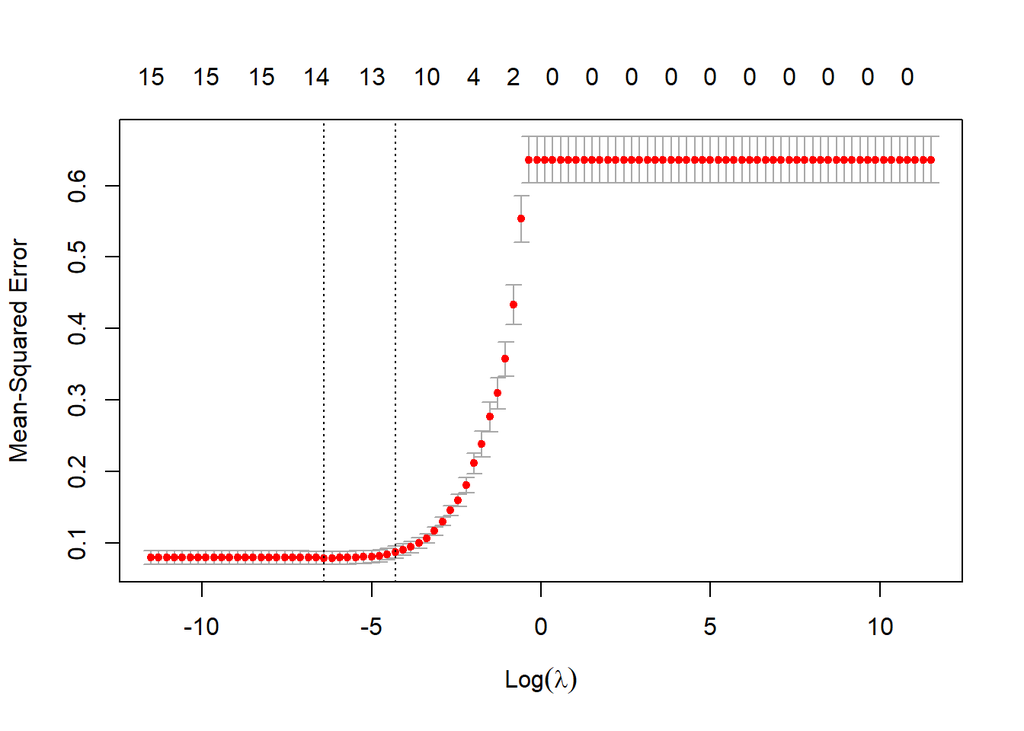

```r
#Create what we need
sleep.mm <- model.matrix(Sleep.Duration ~ ., data = sleep)
sleep.mm <- sleep.mm[, -1] #unlike for BSS, here we must pass a matrix, not a data frame
y <- sleep$Sleep.Duration
lambda.grid <- 10^seq(5, -5, length = 100)

#Estimate the best model
lasso <- cv.glmnet(sleep.mm, y, alpha = 1, lambda = lambda.grid)
plot(lasso)
```

```r
bestlam <- lasso$lambda.min #extract best lambda value
```

We extracted the value of $\lambda$ which gives the lowest CV test error over all data, which is:

```r
lasso$cvm[which.min(lasso$cvm)]
```

```
## [1] 0.07942145
```

Now we refit using all data and the same grid of $\lambda$ values and then we extract the coefficients corresponding to the best model in terms of prediction accuracy.

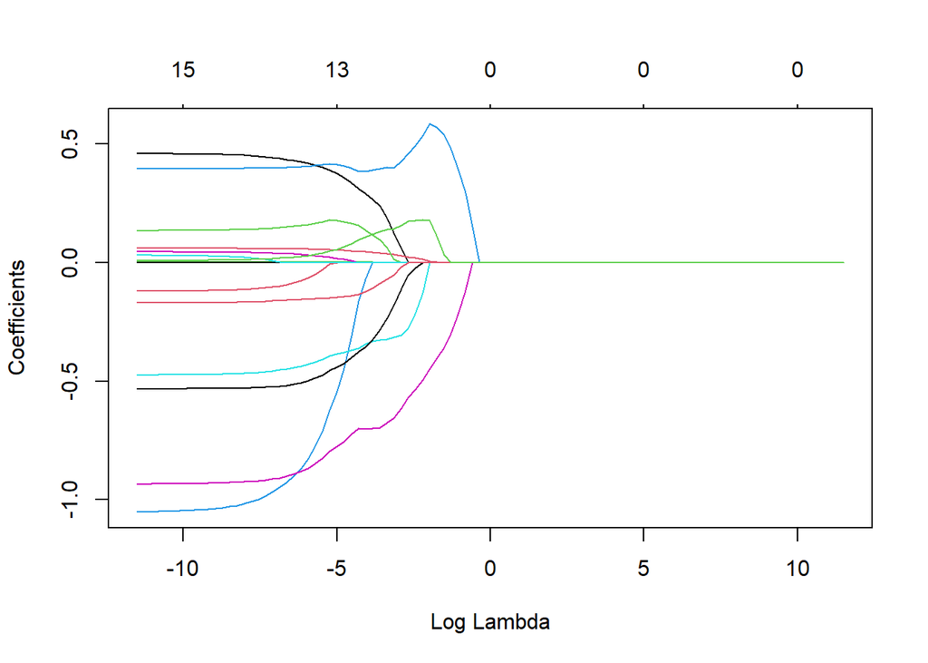

```r
final <- glmnet(sleep.mm, y, alpha = 1, lambda = lambda.grid)
plot(final, xvar = 'lambda')
```

```r
model.coeffs <- predict(final, type = 'coefficients', s = bestlam)
model.coeffs[1:16, ]
```

```
##               (Intercept)                GenderMale                       Age
##              2.689858e+00              4.315513e-01              5.860945e-02
##   Physical.Activity.Level         BMI.CategoryObese    BMI.CategoryOverweight
##              4.578940e-03             -8.995741e-01             -4.426841e-01
##                Heart.Rate               Daily.Steps        Sleep.DisorderNone
##              3.718310e-02             -8.593852e-05             -8.469411e-02
## Sleep.DisorderSleep Apnea       Sleep.Qual.simpGood        Stress.Lev.simpLow
##              1.537882e-01              4.025759e-01              0.000000e+00
##  Stress.Lev.simpVery High   Blood.Pressure.simpHigh Blood.Pressure.simpNormal
##             -8.923203e-01             -5.133531e-01             -1.562086e-01
##       Occupation.simpSTEM
##              2.388388e-02
```

## Conclusions

### Classification Part

Using as response variable **Quality.of.Sleep**, we were able to build two pretty accurate classifiers: one using a Discriminant Analysis approach and the other using a classification trees approach; both these approaches brought us models with more or less the same prediction error, however, using trees we were also able to understand which variables are more important for a better sleep. In particular, we understood that the predictors **Sleep.Duration**, **Stress.Level**, **Blood.Pressure** and **Occupation** are the ones that matter the most in explaining the response **Quality.of.Sleep**.

### Regression Part

Using as response variable **Sleep.Duration**, we used a classical Multiple Linear regression to build a model to predict it; after we checked if the linear assumption is reasonable for this data set, we found the best model using Best Subset Selection: we tried to use different ways to select the best model, and all of these brought us more or less the same predictors. In particular, using Cross Validation, we got a pretty complex model of $p = 10$ variables (without dummies), however, using the one-standard-error rule, we selected a simpler model with $p = 6$ (without dummies), which is a little less accurate than the best. However it is fine for us to use this since our goal is to understand which variables are more important in explaining the response. From this model, we found out that the most important predictors are: **Gender**, **Age**, **Body Mass Index**, **Heart Rate**, **Stress Level**, **Blood.Pressure**.

### Summing Up

We saw that all these different techniques bring us slightly different models, however, in the end, the most important predictors remain the same: we can conclude that in order to sleep better and longer, we should take care of our health, both at a physical and mental level, since both not being in a good shape and being too stressed can influence our sleep, in multiple manners. We could also argue that, in turn, being in a good mental and physical shape can be influenced by the job of an individual: some can bring a person to be more stressed, or to stay too much time seated, and it is well-known that sedentary lifestyle is not good for our health.

# References

Cutting, Ben. 2025. “Health and Sleep Relation 2024.” Mendeley Data. https://doi.org/10.17632/46j8wrc7p7.1.